# Curso Intensivo de Introducción al lenguaje R

Clase 1 - Introducción a R Base

# Descripción del programa

[figure not shown]

https://cran.r-project.org/

## ¿Que es R?

- Lenguaje para el procesamiento y análisis estadístico de datos
- Software Libre
- Sintaxis Básica: R base
- Sintaxis incremental[^1]: El lenguaje se va ampliando por aportes de Universidades, investigadores/as, usuarios/as y empresas privadas, organizados en librerías (o paquetes)

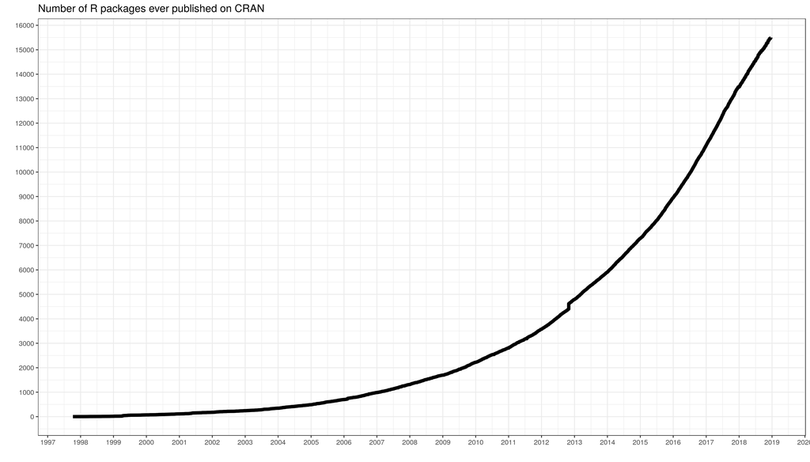

fuente: https://gist.github.com/daroczig/3cf06d6db4be2bbe3368

https://www.rstudio.com/

El *entorno* más cómodo para utilizar el *lenguaje* **R** es el *programa* **R studio**

- Rstudio es una empresa que produce productos asociados al lenguaje R, como el programa sobre el que corremos los comandos, y extensiones del lenguaje (librerías).
- El programa es *gratuito* y se puede bajar de la [página oficial](https://www.rstudio.com/)

[figure not shown]

Pantalla Rstudio

## Diferencias con STATA y SPSS

- Gratuito
- Funciona principalmente por líneas de código (Aunque ya hay paquetes que permiten ejecutar comandos desde el menú y los botones sin tener que esribir código)
- Trabaja las bases de microdatos de forma virtual y no fisica, lo que permite disponer de varias al mismo tiempo sin mayor dificultad (no requiere abrir cada base, trabajarla por separado y luego cerrarla), ni exije guardar fisicamente los cambios.
- Más potente
  - Totalmente automatizable
  - Aportes de usuarias y usuarios
  - Extensible a otros lenguajes y usos (presentación como esta, diseño de aplicaciones)
- Más veloz:

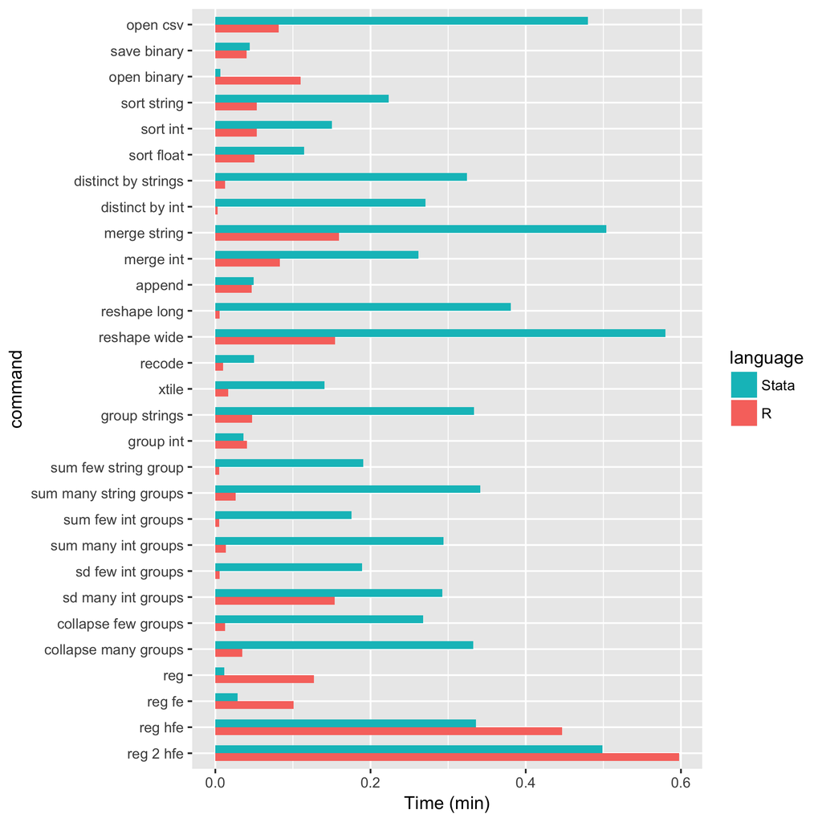

fuente: https://github.com/matthieugomez/benchmark-stata-r/blob/master/output/1e7.png

# Lógica sintáctica en R base

Con *R base* nos referimos a los comandos básicos que vienen incorporados en el R, sin necesidad de cargar librerías.

## Objetos

Los **Objetos/Elementos** constituyen la categoría escencial del R. De hecho, todo en R es un objeto, y se almacena con un nombre específico que **no debe poseer espacios**. Un número, un vector, una función, la progresión de letras del abecedario, una base de datos, un gráfico, constituyen para R objetos de distinto tipo. Los objetos que vamos creando a medida que trabajamos pueden visualizarse en la panel derecho superior de la pantalla (“Environment”).

## Operadores

Los operadores son los símbolos que le indican a R que debe realizar una tarea. Mediante la combinación de datos y operadores es que logramos que R haga su trabajo.

Existen operadores específicos para cada tipo de tarea. Los tipos de operadores principales son los siguientes:

- De asignación
- Aritméticos
- Relacionales
- Lógicos

### Operadores de asignación

- **<-**
- **=**

Ambos operadores sirven para definir objetos, es decir, asignarle un valor. Sin embargo, en la práctica se suele utilizar el operador **`<-`** para la definición de objetos, por más que el **`=`** sea equivalente. **A la izquierda** del **`<-`** debe ubicarse el nombre que tomará el elemento a crear. **Del lado derecho** debe ir la definición del mismo.

Veamos un ejemplo:

```r
A <- 1
A
```

```
[1] 1
```

Al definir un elemento, el mismo queda guardado en el ambiente del programa, y podrá ser utilizado posteriormente para observar su contenido o para realizar una operación con el mismo.

```r
A + 6
```

```
[1] 7
```

Al correr una linea con el nombre del objeto, la consola del programa nos muestra su contenido. Entre corchetes observamos el número de orden del elemento en cuestión.

```r
B <- 2
B
```

```
[1] 2
```

**`<-`** es un operador **Unidireccional**, es decir que:  
`A <- B` implica que **A** va tomar como valor el contenido del objeto **B**, y no al revés.

```r
A <- B

#Ahora A toma el valor de B, y B continua conservando el mismo valor
A
```

```
[1] 2
```

```r
B
```

```
[1] 2
```

En R, cuando se define un objeto con el mismo nombre de un objeto previamente existente, el último reemplaza al primero.

### Operadores aritméticos:

- Suma: `+`
- Resta: `-`
- Cociente: `/`
- Multiplicación: `*`
- Potencia: `^`

```r
#suma
A <- 5+6
A
```

```
[1] 11
```

```r
#Resta
B <- 6-8
B
```

```
[1] -2
```

```r
#cociente
C <- 6/2
C
```

```
[1] 3
```

```r
#multiplicacion
D <- 6*2
D
```

```
[1] 12
```

```r
E <- 3^3
E
```

```
[1] 27
```

### Operadores lógicos relacionales:

Los operadores lógicos son usados para describir relaciones, expresadas como verdadero (TRUE) o falso (FALSE).

- Mayor: `>`
- Mayor o igual: `>=`
- Menor: `<`
- Menor o igual: `<=`
- Igual: `==`
- Distinto: `!=`

```r
#Redefinimos los valores A y B
A <- 10
B <- 20

#Realizamos comparaciones lógicas
A > B
```

```
[1] FALSE
```

```r
A >= B
```

```
[1] FALSE
```

```r
A < B
```

```
[1] TRUE
```

```r
A <= B
```

```
[1] TRUE
```

```r
A == B
```

```
[1] FALSE
```

```r
A != B
```

```
[1] TRUE
```

```r
C <- A != B
C
```

```
[1] TRUE
```

Como muestra el último ejemplo, el resultado de una operación lógica puede almacenarse como el valor de un objeto.

### Otros operadores lógicos:

- Ó: `|`
- Y: `&`

```r
#Redefinimos los valores A y B
A <- 10
B <- 20
#Realizamos comparaciones lógicas

(A | B) > 30
```

```
[1] FALSE
```

```r
(A & B) <= 30
```

```
[1] TRUE
```

## Caracteres especiales

- R es sensible a mayúsculas y minúsculas, tanto para los nombres de las variables, como para las funciones y parámetros.
- Los **espacios en blanco** y los **carriage return** (*enter*) no son considerados por el lenguaje. Los podemos aprovechar para emprolijar el código y que la lectura sea más simple[^2].
- El **numeral** `#` se utiliza para hacer comentarios. Todo lo que se escribe después del # no es interpretado por R. Se debe utilizar un # por cada línea de código que se desea anular
- Los **corchetes** `[]` se utilizan para acceder a un objeto:
  - en un vector[n° orden]
  - en una tabla[fila, columna]
  - en una lista[n° elemento]
- el signo **$** también es un método de acceso. Particularmente, en los dataframes, nos permitira acceder a una determinada columna de una tabla
- Los **paréntesis**`()` se utilizan en las funciones para definir los parámetros.
- Las **comas** `,` se utilizan para separar los parametros al interior de una función.

## Tipos de Objetos:

Existen un gran cantidad de objetos distintos en R, en lo que respecta al curso trabajaremos principalmente con 4 de ellos:

- Valores
- Vectores
- Data Frames
- Listas

### Valores

Los valores pueden ser de distintas *clases*:  
**Valores “Numeric” (numéricos)**

```r
A <- 1
class(A)
```

```
[1] "numeric"
```

**Valores ‘Character’ (caracter)**

```r
A <- "Hola"
class(A)
```

```
[1] "character"
```

```r
A <- "Hola, ¿qué tal?"
class(A)
```

```
[1] "character"
```

```r
A <- paste('Hola,', '¿qué tal?', sep = " ")
A
```

```
[1] "Hola, ¿qué tal?"
```

```r
class(A)
```

```
[1] "character"
```

**Valores de tipo ‘factor’**

En general, es un dato numérico representado por una etiqueta.

```r
valor1 <- "A"
class(valor1)
```

```
[1] "character"
```

```r
valor2 <- factor("A")
valor2
```

```
[1] A
Levels: A
```

```r
# Otra forma de definir al factor
valor2 <- factor(valor1)
valor2
```

```
[1] A
Levels: A
```

```r
class(valor2)
```

```
[1] "factor"
```

```r
# Una propiedad del factor: las etiquetas.
valor3 <- factor("A",
                 labels = "Letra A")
class(valor3)
```

```
[1] "factor"
```

```r
valor3
```

```
[1] Letra A
Levels: Letra A
```

La diferencia entre un *character* y un *factor* es que el último tiene solo algunos valores permitidos (levels), con un orden interno predefinido (el cual ,por ejemplo, se respetará a la hora de realizar un gráfico)